# Plots and basic analysis of results

```r
library(ggplot2)
library(readr)
library(dplyr)
```

```r
folder_home <- "../../../"
folder_in <- paste0(folder_home,"Results/svm/Tables/")
folder_out <- paste0(folder_home,"Results/svm/Figures/")
save_figs = FALSE #Whether or not to save the figures
```

```r
### Load data
propublica = read_csv(paste0(folder_home,"Data/1_raw/compas-scores-two-years.csv"))
res_decile = read_csv(paste0(folder_in,'svm_output_bin_decile_score.csv'))
res_decile3 = read_csv(paste0(folder_in,'svm_output_bin_decile_score3.csv'))
res_decile8 = read_csv(paste0(folder_in,'svm_output_bin_decile_score8.csv'))
res_race = read_csv(paste0(folder_in,'svm_output_bin_race.csv'))
```

```r
# Some data processing for the plot
ds = .09
df_plt <- res_decile %>%
  mutate(mid=(LB+UB)/2) %>%
  arrange(decile_score, mid) %>%
  group_by(decile_score) %>%
  mutate(rank = 1:n()) %>%
  mutate(score_jitter = decile_score + ds*1:n() - ds*(n()+1)/2) %>%
  mutate(two_year_recid = as.factor(two_year_recid)) %>%
  mutate(is_recid_plt =  ifelse(two_year_recid==1,"Reoffend",""))
```

[figure not shown]

```r
id_ann <- c(4704, 2825, 4772, 8731, 9346, 10258, 3338, 7534, 6749, 4797, 40)
ann_line <- filter(df_plt, id%in%id_ann) %>%
  mutate(yend = UB+.5)
ann_text <- left_join(ann_line,propublica,by="id") %>% ungroup()
score_min = min(res_decile$decile_score)
score_max = max(res_decile$decile_score)
p <- ggplot(df_plt, aes(x=score_jitter)) +
  #geom_segment(data=ann_line,aes(x = score_jitter, xend = score_jitter, y = 20, yend = 0,color=factor(id)),
  #             size=.5, arrow=arrow(length=unit(0.15,"cm")))+
  geom_text(data=ann_text, aes(x=score_jitter, y=5.5, label=name),angle=90,hjust='left',size=2)+
  geom_segment(data=ann_line,aes(x = score_jitter, xend = score_jitter, y = 5, yend = yend),
               color='black',size=.5, arrow=arrow(length=unit(0.15,"cm")))+
  geom_errorbar(aes(ymin=LB, ymax=UB, color=race),
                width=.05) +
  geom_point(aes(y=UB+.1, shape=is_recid_plt), size=.8) +
  scale_shape_manual(values=c(32,16), name=element_blank()) + # values are for Reoffend character
  geom_hline(yintercept=0, color='grey', linetype=2) +
  theme_bw() +
  scale_x_continuous(breaks=seq(score_min,score_max),
                     limits=c(score_min-0.5, score_max+0.5),
                     expand=c(0,0))+
  theme(panel.grid.major.x = element_line(colour="white", size=0.5),
        panel.grid.major.y = element_blank(),
        panel.grid.minor.y = element_blank(),
        legend.position="bottom") +
  xlab("COMPAS Score") +
  ylab("Scaled Distance to Hyperplane") +
  scale_color_discrete(name="")
p
```

```r
if (save_figs){
  ggsave(paste0(folder_out,"svm_by_decile.pdf"),p,width = 8, height = 4, units = "in")
}
```

### COMPAS score of 3

Fraction of people on either side of zero:

```r
sum(res_decile3$LB<0 & res_decile3$UB > 0 )/nrow(res_decile3)
```

```
[1] 0.7496229
```

How many people had an interval above zero (and a low compas score in this case)?

```r
res_decile3 %>%
  filter(LB > 0)
```

| id | race | decile_score | score_text | two_year_recid | LB | UB | LB_geo | UB_geo | flag_min | flag_max |
| --- | --- | --- | --- | --- | --- | --- | --- | --- | --- | --- |
| 2193 | Caucasian | 3 | Low | 1 | 0.075094523 | 2.119772 | 0.092852520 | 2.479609 | 1 | 1 |
| 2968 | African-American | 3 | Low | 1 | 0.083712014 | 1.521858 | 0.118550685 | 1.608139 | 1 | 1 |
| 8268 | Caucasian | 3 | Low | 0 | 0.331364170 | 1.447634 | 0.511647303 | 1.353768 | 1 | 1 |
| 7007 | African-American | 3 | Low | 0 | 0.120270488 | 1.602231 | 0.165960815 | 1.817949 | 1 | 1 |
| 1516 | Hispanic | 3 | Low | 1 | 0.172766755 | 1.536216 | 0.165035538 | 1.419780 | 1 | 1 |
| 10932 | African-American | 3 | Low | 0 | 0.331364170 | 1.447634 | 0.511647303 | 1.353768 | 1 | 1 |
| 456 | Caucasian | 3 | Low | 0 | 0.331364170 | 1.447634 | 0.511647303 | 1.353768 | 1 | 1 |
| 7559 | Caucasian | 3 | Low | 0 | 0.276612146 | 1.490103 | 0.268998262 | 1.451550 | 1 | 1 |
| 8675 | Caucasian | 3 | Low | 0 | 0.329831580 | 1.446032 | 0.509459926 | 1.416596 | 1 | 1 |
| 3454 | African-American | 3 | Low | 1 | 0.193971377 | 2.119932 | 0.211949107 | 2.479537 | 1 | 1 |

[output cut: 65 more lines]

What can we say about this group on average?

```r
above0_score3 = filter(propublica, id %in% res_decile3$id[res_decile3$LB>0]) %>%
  summarize(n_people = n(), mean_prior=mean(priors_count), tot_recid=sum(two_year_recid))
above0_score3
```

| n_people | mean_prior | tot_recid |
| --- | --- | --- |
| 75 | 6.373333 | 35 |

Of the 663 people in our dataset with COMPAS scores of 3, 75 of them had hacking intervals entirely above zero. That is, had SVM been used for prediction, any reasonable model would have predicted that they would reoffend. These people had an average of nearly 6.3733333 priors and35 of them reoffended.

# This includes 56 year old Dwight Francis (person id 10623) charged with felony petit theft. He had 20 priors including felony petit theft and felony possession of cocaine. Since his COMPAS score was calculated he has been arrested on three occasions for misdomeanor felony petit theft. Update: Dwight Francis no longer has interval above zero. Need to find other example.

```r
# Some data processing for the plot
ds = .04
df3_plt <- res_decile3 %>%
  mutate(mid=(LB+UB)/2) %>%
  arrange(decile_score, mid) %>%
  group_by(decile_score) %>%
  mutate(rank = 1:n()) %>%
  mutate(score_jitter = decile_score + ds*1:n() - ds*(n()+1)/2) %>%
  mutate(two_year_recid = as.factor(two_year_recid)) %>%
  mutate(is_recid_plt =  ifelse(two_year_recid==1,"Reoffend","")) %>%
  mutate(group = if_else(row_number()<=floor(nrow(res_decile3)/3),0,if_else(row_number()>floor(nrow(res_decile3)/3) & row_number()<=floor(nrow(res_decile3)*2/3),2,3)))
```

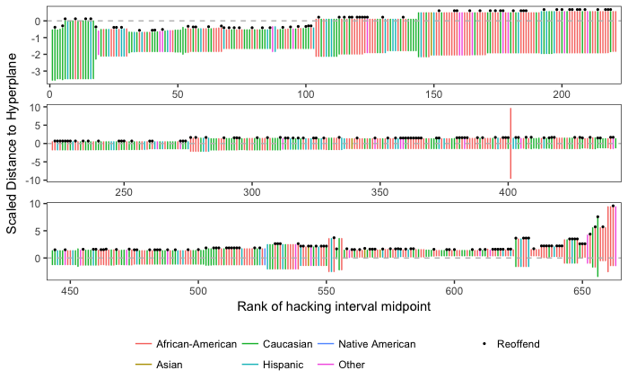

```r
ann_line <- data.frame(x = 659, xend = 659, y = -2.5, yend = 0, group=3)
ann_text <- data.frame(x = 650, xend = 659, y = -2.8, yend = 0, group=3)
p<-ggplot(df3_plt, aes(x=rank)) +
  geom_errorbar(aes(ymin=LB, ymax=UB, color=race),
                width=.05) +
  geom_point(aes(y=UB+.1, shape=is_recid_plt), size=.8) +
  scale_shape_manual(values=c(32,16), name=element_blank()) + # values are for Reoffend character
  geom_hline(yintercept=0, color='grey', linetype=2) +
  #geom_segment(data=ann_line,aes(x = x, xend = xend, y = y, yend = yend),
               #colour = "black", size=.5, arrow=arrow(length=unit(0.15,"cm")))+
  #geom_text(data=ann_text,aes(x=x,y=y,size=2),label="Dwight Francis",size=3)+
  facet_wrap(~group ,scales = "free",ncol=1) +
  theme_bw() +
  scale_x_continuous(expand=c(0.01,0.01)
                     #                  breaks=seq(score_min,score_max),
                     #                   limits=c(score_min-0.5, score_max+0.5),
  )+
  theme(strip.background = element_blank(),
        strip.text = element_blank(),
        #axis.title.x=element_blank(),
        #axis.text.x=element_blank(),
        #axis.ticks.x=element_blank(),
        panel.grid.minor.x = element_blank(),
        panel.grid.major.x = element_blank(),
        panel.grid.major.y = element_blank(),
        panel.grid.minor.y = element_blank(),
        legend.position="bottom") +
  ylab("Scaled Distance to Hyperplane") +
  xlab("Rank of hacking interval midpoint") +
  scale_color_discrete(name="")
p
```

```r
if (save_figs){
ggsave(paste0(folder_out,"svm_by_decile3.pdf"),p,width = 8, height = 4, units = "in")
}
```

## COMPAS score of 8

Number of people on either side of zero:

```r
sum(res_decile8$LB<0 & res_decile8$UB > 0 )/nrow(res_decile8)
```

```
[1] 0.6682243
```

How many people had an interval below zero (and a high compas score in this case)?

```r
res_decile8 %>%
  filter(UB < 0)
```

| id | race | decile_score | score_text | two_year_recid | LB | UB | LB_geo | UB_geo | flag_min | flag_max |
| --- | --- | --- | --- | --- | --- | --- | --- | --- | --- | --- |
| 3112 | African-American | 8 | High | 0 | -1.676170 | -0.5116623 | -1.693489 | -0.7017749 | 1 | 1 |
| 8434 | African-American | 8 | High | 1 | -1.676083 | -0.5116505 | -1.693496 | -0.7015199 | 1 | 1 |
| 6705 | Caucasian | 8 | High | 0 | -2.128498 | -0.4862226 | -2.454687 | -0.5742689 | 1 | 1 |
| 2131 | African-American | 8 | High | 0 | -1.676083 | -0.5116505 | -1.693496 | -0.7015199 | 1 | 1 |
| 7688 | African-American | 8 | High | 0 | -1.676146 | -0.5096036 | -1.693595 | -0.6993944 | 1 | 1 |
| 800 | African-American | 8 | High | 1 | -3.482226 | -0.5398781 | -2.897353 | -0.6231082 | 1 | 1 |
| 6884 | Caucasian | 8 | High | 0 | -1.675700 | -0.4008138 | -1.694366 | -0.4940544 | 1 | 1 |
| 6961 | African-American | 8 | High | 1 | -1.858453 | -0.6508947 | -1.956780 | -0.8185083 | 1 | 1 |
| 10289 | Caucasian | 8 | High | 1 | -1.678192 | -0.5100927 | -1.694221 | -0.6999118 | 1 | 1 |
| 10274 | African-American | 8 | High | 1 | -1.858346 | -0.6641831 | -1.956924 | -0.8998791 | 1 | 1 |

[output cut: 11 more lines]

What can we say about this group on average?

```r
above0_score8 = filter(propublica, id %in% res_decile8$id[res_decile8$LB>0]) %>%
  summarize(n_people = n(), mean_prior=mean(priors_count), tot_recid=sum(two_year_recid))
above0_score8
```

| n_people | mean_prior | tot_recid |
| --- | --- | --- |
| 121 | 8.752066 | 94 |